# K-fold Factor Analysis - Endline

October 30, 2022

# Overview

**# of folds:** 2

**# of variables:** 21

**# of observations:** 241

**Maximum # of factors:**

- Allowed - 6
- Extracted - 5

**Estimation:** ML

**Missing Data:** listwise

# Model Summary

**Fit across folds by factor model**

| model | df.scaled | chisq.scaled mean | chisq.scaled range | cfi.scaled mean | cfi.scaled range | rmsea.scaled mean | rmsea.scaled range |
| --- | --- | --- | --- | --- | --- | --- | --- |
| 1-factor | 35.76685 | 60.82 | 52.82 - 68.82 | 0.48 | 0.29 - 0.66 | 0.08 | 0.06 - 0.09 |
| 2-factor | 31.55640 | 33.41 | 33.41 - 33.41 | 0.92 | 0.92 - 0.92 | 0.02 | 0.02 - 0.02 |
| 3-factor | 34.39958 | 37.38 | 37.38 - 37.38 | 0.91 | 0.91 - 0.91 | 0.03 | 0.03 - 0.03 |
| 4-factor | 30.82403 | 27.56 | 27.56 - 27.56 | 1.00 | 1.00 - 1.00 | 0.00 | 0.00 - 0.00 |
| 5-factor | 28.96848 | 28.83 | 28.83 - 28.83 | 1.00 | 1.00 - 1.00 | 0.00 | 0.00 - 0.00 |

**Count of folds out of 2 with flagged problems**

[output not shown]

# Model Details

## 1-factor

**Factor Structure**

f1 =~ capable_person_e + confident_abt_future_e + comfortable_who_i_am_e + feel_smart_e + respect_lookup_e + worried_other_think_e + belong_school_e + people_accept_e + comfortable_at_school_e + worry_abt_dumb_e + nervous_worried_e + worry_ppl_dislike_e + conclusion_other_deaf_e + conclusion_my_perform_e + conclusion_abt_me_e + bad_grades_e + not_understand_class_e + not_understand_homework_e + bad_class_teacher_e + trouble_studying_e + pressure_parent_teacher_e

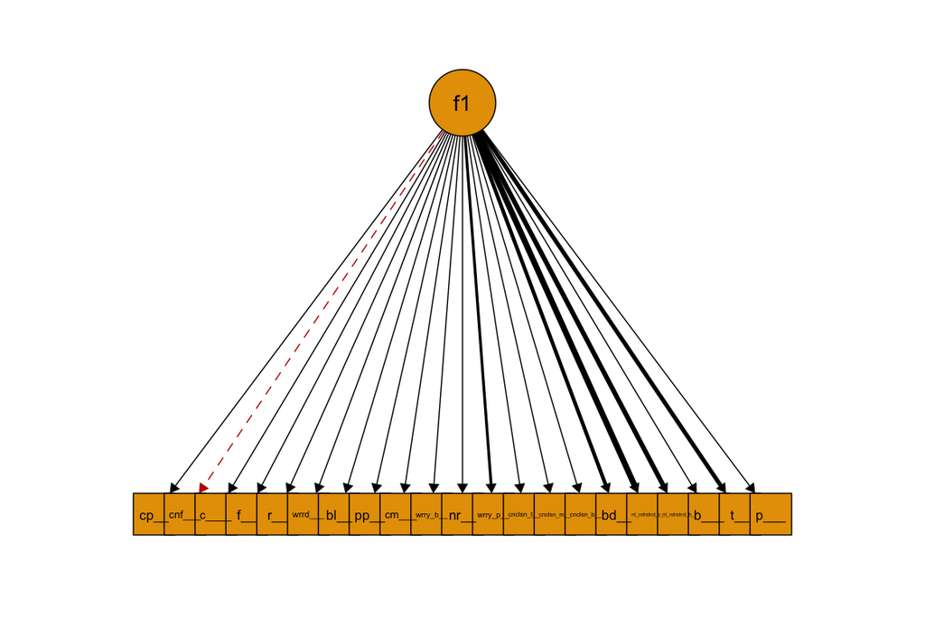

**Standardized Loading Across Folds**

| variable | mean | range | loading flag | heywood flag |
| --- | --- | --- | --- | --- |
| capable_person_e | 0.18 | 0.08 - 0.27 | 2 | 0 |
| confident_abt_future_e | 0.00 | -0.10 - 0.10 | 2 | 0 |
| comfortable_who_i_am_e | 0.09 | 0.09 - 0.09 | 2 | 0 |
| feel_smart_e | 0.06 | -0.03 - 0.15 | 2 | 0 |
| respect_lookup_e | 0.22 | 0.13 - 0.31 | 1 | 0 |
| worried_other_think_e | -0.03 | -0.42 - 0.36 | 1 | 0 |
| belong_school_e | 0.11 | 0.05 - 0.17 | 2 | 0 |
| people_accept_e | 0.24 | 0.22 - 0.25 | 2 | 0 |
| comfortable_at_school_e | -0.02 | -0.07 - 0.04 | 2 | 0 |
| worry_abt_dumb_e | -0.01 | -0.37 - 0.36 | 1 | 0 |
| nervous_worried_e | 0.01 | -0.20 - 0.22 | 2 | 0 |
| worry_ppl_dislike_e | 0.01 | -0.46 - 0.49 | 1 | 0 |
| conclusion_other_deaf_e | -0.08 | -0.45 - 0.29 | 2 | 0 |
| conclusion_my_perform_e | -0.04 | -0.50 - 0.41 | 1 | 0 |
| conclusion_abt_me_e | -0.14 | -0.52 - 0.23 | 2 | 0 |
| bad_grades_e | -0.03 | -0.58 - 0.53 | 1 | 0 |
| not_understand_class_e | 0.03 | -0.57 - 0.62 | 1 | 0 |
| not_understand_homework_e | 0.03 | -0.52 - 0.57 | 1 | 0 |
| bad_class_teacher_e | -0.12 | -0.62 - 0.38 | 1 | 0 |
| trouble_studying_e | -0.02 | -0.60 - 0.55 | 1 | 0 |
| pressure_parent_teacher_e | -0.07 | -0.51 - 0.36 | 1 | 0 |

Note: loadings flagged when < 0.3 in a fold. ‘heywood flag’ is the number of folds the variable’s estimated residual variance was negative

**Scale Reliability Across Folds**

| factor | omega_h mean | omega_h range | omega_h flag | alpha mean | alpha range | alpha flag |
| --- | --- | --- | --- | --- | --- | --- |
| f1 | 0.72 | 0.71 - 0.72 | 0 | 0.61 | 0.59 - 0.63 | 1 |

Note: ‘flag’ is the number of folds the scale had a reliability < 0.6

## 2-factor

**Factor Structure**

f1 =~ capable_person_e + confident_abt_future_e + comfortable_who_i_am_e + respect_lookup_e + belong_school_e + people_accept_e + bad_grades_e + not_understand_class_e + not_understand_homework_e + bad_class_teacher_e + trouble_studying_e + pressure_parent_teacher_e

f2 =~ feel_smart_e + worried_other_think_e + comfortable_at_school_e + worry_abt_dumb_e + nervous_worried_e + worry_ppl_dislike_e + conclusion_other_deaf_e + conclusion_my_perform_e + conclusion_abt_me_e

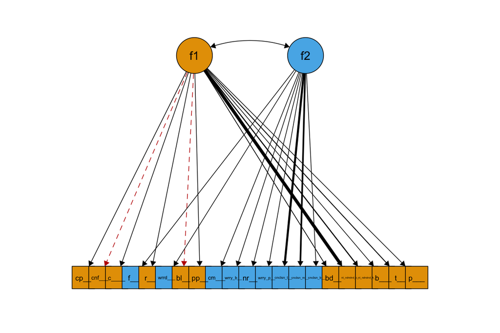

**Standardized Loading Across Folds**

| variable | mean | range | loading flag | heywood flag |
| --- | --- | --- | --- | --- |
| capable_person_e | 0.19 | 0.19 - 0.19 | 1 | 0 |
| confident_abt_future_e | -0.07 | -0.07 - -0.07 | 1 | 0 |
| comfortable_who_i_am_e | 0.07 | 0.07 - 0.07 | 1 | 0 |
| feel_smart_e | 0.08 | 0.08 - 0.08 | 1 | 0 |
| respect_lookup_e | 0.27 | 0.27 - 0.27 | 1 | 0 |
| worried_other_think_e | 0.38 | 0.38 - 0.38 | 0 | 0 |
| belong_school_e | -0.05 | -0.05 - -0.05 | 1 | 0 |
| people_accept_e | 0.14 | 0.14 - 0.14 | 1 | 0 |
| comfortable_at_school_e | 0.17 | 0.17 - 0.17 | 1 | 0 |
| worry_abt_dumb_e | 0.24 | 0.24 - 0.24 | 1 | 0 |
| nervous_worried_e | 0.25 | 0.25 - 0.25 | 1 | 0 |
| worry_ppl_dislike_e | 0.43 | 0.43 - 0.43 | 0 | 0 |
| conclusion_other_deaf_e | 0.66 | 0.66 - 0.66 | 0 | 0 |
| conclusion_my_perform_e | 0.63 | 0.63 - 0.63 | 0 | 0 |
| conclusion_abt_me_e | 0.54 | 0.54 - 0.54 | 0 | 0 |
| bad_grades_e | 0.56 | 0.56 - 0.56 | 0 | 0 |
| not_understand_class_e | 0.75 | 0.75 - 0.75 | 0 | 0 |
| not_understand_homework_e | 0.58 | 0.58 - 0.58 | 0 | 0 |
| bad_class_teacher_e | 0.50 | 0.50 - 0.50 | 0 | 0 |
| trouble_studying_e | 0.57 | 0.57 - 0.57 | 0 | 0 |
| pressure_parent_teacher_e | 0.34 | 0.34 - 0.34 | 0 | 0 |

Note: loadings flagged when < 0.3 in a fold. ‘heywood flag’ is the number of folds the variable’s estimated residual variance was negative

**Mean Factor Correlations**

|  | f1 | f2 | flag |
| --- | --- | --- | --- |
| f1 | 1.00 |  | 0 |
| f2 | 0.37 | 1.00 | 0 |

Note: ‘flag’ is the number of folds the factor had a correlation > 0.9

**Scale Reliability Across Folds**

| factor | omega_h mean | omega_h range | omega_h flag | alpha mean | alpha range | alpha flag |
| --- | --- | --- | --- | --- | --- | --- |
| f1 | 0.65 | 0.65 - 0.65 | 0 | 0.55 | 0.55 - 0.55 | 1 |
| f2 | 0.62 | 0.62 - 0.62 | 0 | 0.60 | 0.60 - 0.60 | 0 |

Note: ‘flag’ is the number of folds the scale had a reliability < 0.6

## 3-factor

**Factor Structure**

f1 =~ capable_person_e + confident_abt_future_e + feel_smart_e + respect_lookup_e + belong_school_e + people_accept_e + comfortable_at_school_e

f2 =~ worried_other_think_e + worry_abt_dumb_e + nervous_worried_e + worry_ppl_dislike_e + conclusion_other_deaf_e + conclusion_my_perform_e + conclusion_abt_me_e

f3 =~ comfortable_who_i_am_e + bad_grades_e + not_understand_class_e + not_understand_homework_e + bad_class_teacher_e + trouble_studying_e + pressure_parent_teacher_e

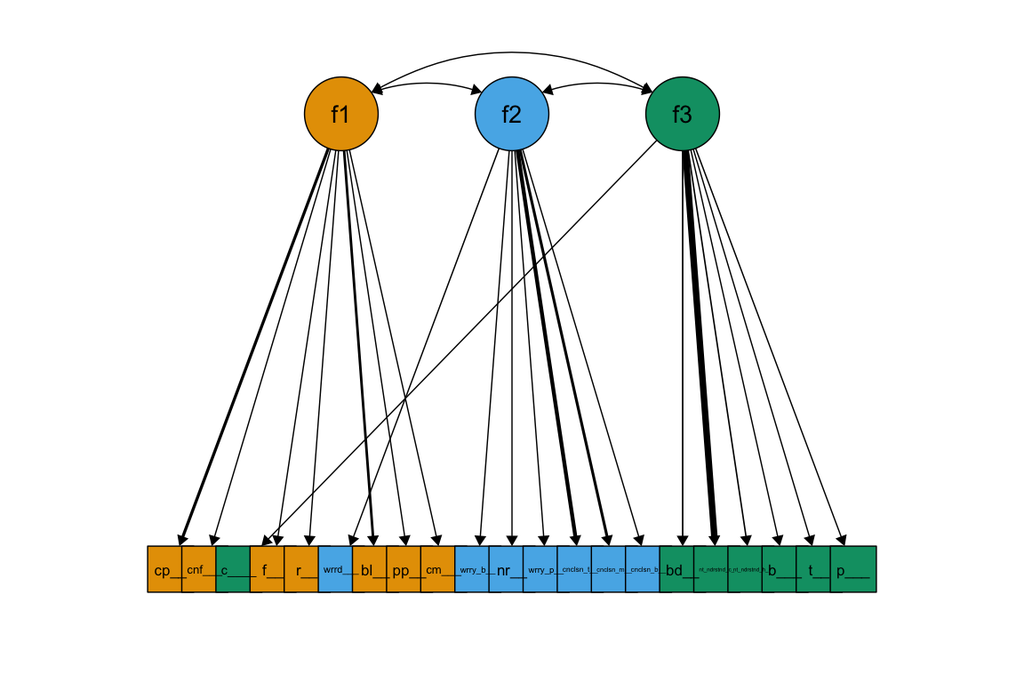

**Standardized Loading Across Folds**

| variable | mean | range | loading flag | heywood flag |
| --- | --- | --- | --- | --- |
| capable_person_e | 0.63 | 0.63 - 0.63 | 0 | 0 |
| confident_abt_future_e | 0.17 | 0.17 - 0.17 | 1 | 0 |
| comfortable_who_i_am_e | 0.05 | 0.05 - 0.05 | 1 | 0 |
| feel_smart_e | 0.51 | 0.51 - 0.51 | 0 | 0 |
| respect_lookup_e | 0.34 | 0.34 - 0.34 | 0 | 0 |
| worried_other_think_e | 0.38 | 0.38 - 0.38 | 0 | 0 |
| belong_school_e | 0.61 | 0.61 - 0.61 | 0 | 0 |
| people_accept_e | 0.51 | 0.51 - 0.51 | 0 | 0 |
| comfortable_at_school_e | 0.27 | 0.27 - 0.27 | 1 | 0 |
| worry_abt_dumb_e | 0.26 | 0.26 - 0.26 | 1 | 0 |
| nervous_worried_e | 0.23 | 0.23 - 0.23 | 1 | 0 |
| worry_ppl_dislike_e | 0.45 | 0.45 - 0.45 | 0 | 0 |
| conclusion_other_deaf_e | 0.67 | 0.67 - 0.67 | 0 | 0 |
| conclusion_my_perform_e | 0.62 | 0.62 - 0.62 | 0 | 0 |
| conclusion_abt_me_e | 0.53 | 0.53 - 0.53 | 0 | 0 |
| bad_grades_e | 0.58 | 0.58 - 0.58 | 0 | 0 |
| not_understand_class_e | 0.77 | 0.77 - 0.77 | 0 | 0 |
| not_understand_homework_e | 0.57 | 0.57 - 0.57 | 0 | 0 |
| bad_class_teacher_e | 0.51 | 0.51 - 0.51 | 0 | 0 |
| trouble_studying_e | 0.56 | 0.56 - 0.56 | 0 | 0 |
| pressure_parent_teacher_e | 0.33 | 0.33 - 0.33 | 0 | 0 |

Note: loadings flagged when < 0.3 in a fold. ‘heywood flag’ is the number of folds the variable’s estimated residual variance was negative

**Mean Factor Correlations**

|  | f1 | f2 | f3 | flag |
| --- | --- | --- | --- | --- |
| f1 | 1.00 |  |  | 0 |
| f2 | 0.31 | 1.00 |  | 0 |
| f3 | 0.10 | 0.35 | 1.00 | 0 |

Note: ‘flag’ is the number of folds the factor had a correlation > 0.9

**Scale Reliability Across Folds**

| factor | omega_h mean | omega_h range | omega_h flag | alpha mean | alpha range | alpha flag |
| --- | --- | --- | --- | --- | --- | --- |
| f1 | 0.59 | 0.59 - 0.59 | 1 | 0.62 | 0.62 - 0.62 | 0 |
| f2 | 0.64 | 0.64 - 0.64 | 0 | 0.62 | 0.62 - 0.62 | 0 |
| f3 | 0.68 | 0.68 - 0.68 | 0 | 0.70 | 0.70 - 0.70 | 0 |

Note: ‘flag’ is the number of folds the scale had a reliability < 0.6

## 4-factor

**Factor Structure**

f1 =~ capable_person_e + confident_abt_future_e + comfortable_who_i_am_e + belong_school_e + people_accept_e + comfortable_at_school_e

f2 =~ feel_smart_e + nervous_worried_e + conclusion_other_deaf_e + conclusion_my_perform_e

f3 =~ bad_grades_e + not_understand_class_e + not_understand_homework_e + bad_class_teacher_e + trouble_studying_e + pressure_parent_teacher_e

f4 =~ respect_lookup_e + worried_other_think_e + worry_abt_dumb_e + worry_ppl_dislike_e + conclusion_abt_me_e

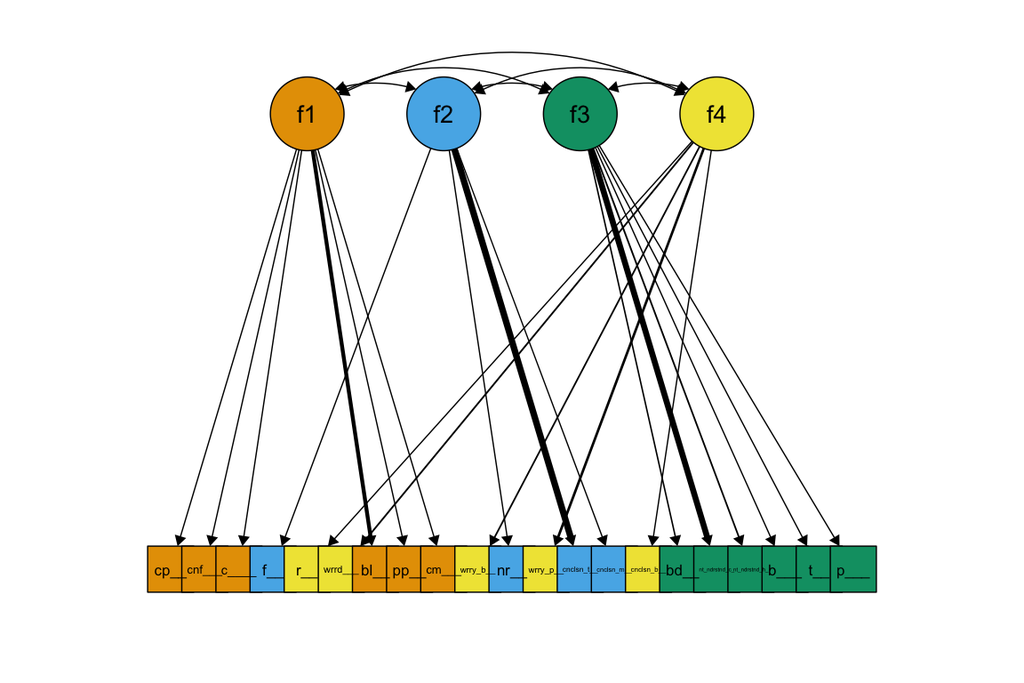

**Standardized Loading Across Folds**

| variable | mean | range | loading flag | heywood flag |
| --- | --- | --- | --- | --- |
| capable_person_e | 0.52 | 0.52 - 0.52 | 0 | 0 |
| confident_abt_future_e | 0.18 | 0.18 - 0.18 | 1 | 0 |
| comfortable_who_i_am_e | 0.43 | 0.43 - 0.43 | 0 | 0 |
| feel_smart_e | 0.14 | 0.14 - 0.14 | 1 | 0 |
| respect_lookup_e | 0.32 | 0.32 - 0.32 | 0 | 0 |
| worried_other_think_e | 0.59 | 0.59 - 0.59 | 0 | 0 |
| belong_school_e | 0.68 | 0.68 - 0.68 | 0 | 0 |
| people_accept_e | 0.56 | 0.56 - 0.56 | 0 | 0 |
| comfortable_at_school_e | 0.30 | 0.30 - 0.30 | 0 | 0 |
| worry_abt_dumb_e | 0.59 | 0.59 - 0.59 | 0 | 0 |
| nervous_worried_e | 0.20 | 0.20 - 0.20 | 1 | 0 |
| worry_ppl_dislike_e | 0.62 | 0.62 - 0.62 | 0 | 0 |
| conclusion_other_deaf_e | 0.78 | 0.78 - 0.78 | 0 | 0 |
| conclusion_my_perform_e | 0.57 | 0.57 - 0.57 | 0 | 0 |
| conclusion_abt_me_e | 0.19 | 0.19 - 0.19 | 1 | 0 |
| bad_grades_e | 0.58 | 0.58 - 0.58 | 0 | 0 |
| not_understand_class_e | 0.76 | 0.76 - 0.76 | 0 | 0 |
| not_understand_homework_e | 0.58 | 0.58 - 0.58 | 0 | 0 |
| bad_class_teacher_e | 0.50 | 0.50 - 0.50 | 0 | 0 |
| trouble_studying_e | 0.57 | 0.57 - 0.57 | 0 | 0 |
| pressure_parent_teacher_e | 0.32 | 0.32 - 0.32 | 0 | 0 |

Note: loadings flagged when < 0.3 in a fold. ‘heywood flag’ is the number of folds the variable’s estimated residual variance was negative

**Mean Factor Correlations**

|  | f1 | f2 | f3 | f4 | flag |
| --- | --- | --- | --- | --- | --- |
| f1 | 1.00 |  |  |  | 0 |
| f2 | 0.36 | 1.00 |  |  | 0 |
| f3 | 0.00 | 0.21 | 1.00 |  | 0 |
| f4 | 0.31 | 0.46 | 0.45 | 1.00 | 0 |

Note: ‘flag’ is the number of folds the factor had a correlation > 0.9

**Scale Reliability Across Folds**

| factor | omega_h mean | omega_h range | omega_h flag | alpha mean | alpha range | alpha flag |
| --- | --- | --- | --- | --- | --- | --- |
| f1 | 0.58 | 0.58 - 0.58 | 1 | 0.60 | 0.60 - 0.60 | 0 |
| f2 | 0.40 | 0.40 - 0.40 | 1 | 0.54 | 0.54 - 0.54 | 1 |
| f3 | 0.72 | 0.72 - 0.72 | 0 | 0.73 | 0.73 - 0.73 | 0 |
| f4 | 0.54 | 0.54 - 0.54 | 1 | 0.63 | 0.63 - 0.63 | 0 |

Note: ‘flag’ is the number of folds the scale had a reliability < 0.6

## 5-factor

**Factor Structure**

f1 =~ capable_person_e + confident_abt_future_e + comfortable_who_i_am_e + comfortable_at_school_e

f2 =~ feel_smart_e + people_accept_e + nervous_worried_e + conclusion_other_deaf_e + conclusion_my_perform_e

f3 =~ respect_lookup_e + belong_school_e

f4 =~ bad_grades_e + not_understand_class_e + not_understand_homework_e + bad_class_teacher_e + pressure_parent_teacher_e

f5 =~ worried_other_think_e + worry_abt_dumb_e + worry_ppl_dislike_e + conclusion_abt_me_e + trouble_studying_e

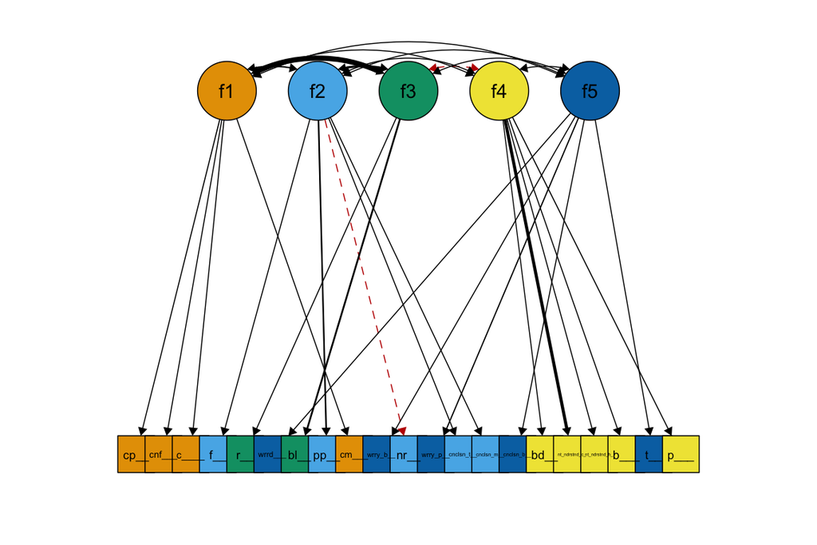

**Standardized Loading Across Folds**

| variable | mean | range | loading flag | heywood flag |
| --- | --- | --- | --- | --- |
| capable_person_e | 0.62 | 0.62 - 0.62 | 0 | 0 |
| confident_abt_future_e | 0.21 | 0.21 - 0.21 | 1 | 0 |
| comfortable_who_i_am_e | 0.42 | 0.42 - 0.42 | 0 | 0 |
| feel_smart_e | 0.41 | 0.41 - 0.41 | 0 | 0 |
| respect_lookup_e | 0.28 | 0.28 - 0.28 | 1 | 0 |
| worried_other_think_e | 0.56 | 0.56 - 0.56 | 0 | 0 |
| belong_school_e | 0.68 | 0.68 - 0.68 | 0 | 0 |
| people_accept_e | 0.66 | 0.66 - 0.66 | 0 | 0 |
| comfortable_at_school_e | 0.30 | 0.30 - 0.30 | 1 | 0 |
| worry_abt_dumb_e | 0.54 | 0.54 - 0.54 | 0 | 0 |
| nervous_worried_e | -0.01 | -0.01 - -0.01 | 1 | 0 |
| worry_ppl_dislike_e | 0.64 | 0.64 - 0.64 | 0 | 0 |
| conclusion_other_deaf_e | 0.48 | 0.48 - 0.48 | 0 | 0 |
| conclusion_my_perform_e | 0.35 | 0.35 - 0.35 | 0 | 0 |
| conclusion_abt_me_e | 0.15 | 0.15 - 0.15 | 1 | 0 |
| bad_grades_e | 0.56 | 0.56 - 0.56 | 0 | 0 |
| not_understand_class_e | 0.78 | 0.78 - 0.78 | 0 | 0 |
| not_understand_homework_e | 0.57 | 0.57 - 0.57 | 0 | 0 |
| bad_class_teacher_e | 0.54 | 0.54 - 0.54 | 0 | 0 |
| trouble_studying_e | 0.45 | 0.45 - 0.45 | 0 | 0 |
| pressure_parent_teacher_e | 0.30 | 0.30 - 0.30 | 1 | 0 |

Note: loadings flagged when < 0.3 in a fold. ‘heywood flag’ is the number of folds the variable’s estimated residual variance was negative

**Mean Factor Correlations**

|  | f1 | f2 | f3 | f4 | f5 | flag |
| --- | --- | --- | --- | --- | --- | --- |
| f1 | 1.00 |  |  |  |  | 1 |
| f2 | 0.65 | 1.00 |  |  |  | 0 |
| f3 | 0.94 | 0.71 | 1.00 |  |  | 1 |
| f4 | 0.15 | 0.19 | -0.11 | 1.00 |  | 0 |
| f5 | 0.19 | 0.47 | 0.26 | 0.52 | 1.00 | 0 |

Note: ‘flag’ is the number of folds the factor had a correlation > 0.9

**Scale Reliability Across Folds**

| factor | omega_h mean | omega_h range | omega_h flag | alpha mean | alpha range | alpha flag |
| --- | --- | --- | --- | --- | --- | --- |
| f1 | 0.40 | 0.40 - 0.40 | 1 | 0.38 | 0.38 - 0.38 | 1 |
| f2 | 0.45 | 0.45 - 0.45 | 1 | 0.36 | 0.36 - 0.36 | 1 |
| f3 | 0.32 | 0.32 - 0.32 | 1 | 0.40 | 0.40 - 0.40 | 1 |
| f4 | 0.68 | 0.68 - 0.68 | 0 | 0.69 | 0.69 - 0.69 | 0 |
| f5 | 0.56 | 0.56 - 0.56 | 1 | 0.62 | 0.62 - 0.62 | 0 |

Note: ‘flag’ is the number of folds the scale had a reliability < 0.6

# Appendix

## Within Fold Model Fit

| fold | 1-factor chisq.scaled | 1-factor df.scaled | 1-factor cfi.scaled | 1-factor rmsea.scaled | 2-factor chisq.scaled | 2-factor df.scaled | 2-factor cfi.scaled | 2-factor rmsea.scaled | 3-factor chisq.scaled | 3-factor df.scaled | 3-factor cfi.scaled | 3-factor rmsea.scaled | 4-factor chisq.scaled | 4-factor df.scaled | 4-factor cfi.scaled | 4-factor rmsea.scaled |
| --- | --- | --- | --- | --- | --- | --- | --- | --- | --- | --- | --- | --- | --- | --- | --- | --- |
| 1 | 68.82 | 35.77 | 0.29 | 0.09 | 33.41 | 31.56 | 0.92 | 0.02 | 37.38 | 34.40 | 0.91 | 0.03 | 27.56 | 30.82 | 1.00 | 0.00 |
| 2 | 52.82 | 35.76 | 0.66 | 0.06 |  |  |  |  |  |  |  |  |  |  |  |  |
| Mean | 60.82 | 35.77 | 0.48 | 0.08 | 33.41 | 31.56 | 0.92 | 0.02 | 37.38 | 34.40 | 0.91 | 0.03 | 27.56 | 30.82 | 1.00 | 0.00 |

| fold | 5-factor chisq.scaled | 5-factor df.scaled | 5-factor cfi.scaled | 5-factor rmsea.scaled |
| --- | --- | --- | --- | --- |
| 1 | 28.83 | 28.97 | 1.00 | 0.00 |
| 2 |  |  |  |  |
| Mean | 28.83 | 28.97 | 1.00 | 0.00 |

## All EFA Structures

### Factors: 1

**Factor Structure Option 1**

**In Folds: 1, 2**

f1 =~ capable_person_e + confident_abt_future_e + comfortable_who_i_am_e + feel_smart_e + respect_lookup_e + worried_other_think_e + belong_school_e + people_accept_e + comfortable_at_school_e + worry_abt_dumb_e + nervous_worried_e + worry_ppl_dislike_e + conclusion_other_deaf_e + conclusion_my_perform_e + conclusion_abt_me_e + bad_grades_e + not_understand_class_e + not_understand_homework_e + bad_class_teacher_e + trouble_studying_e + pressure_parent_teacher_e

### Factors: 2

**Factor Structure Option 1**

**In Folds: 1**

f1 =~ capable_person_e + confident_abt_future_e + comfortable_who_i_am_e + respect_lookup_e + belong_school_e + people_accept_e + bad_grades_e + not_understand_class_e + not_understand_homework_e + bad_class_teacher_e + trouble_studying_e + pressure_parent_teacher_e

f2 =~ feel_smart_e + worried_other_think_e + comfortable_at_school_e + worry_abt_dumb_e + nervous_worried_e + worry_ppl_dislike_e + conclusion_other_deaf_e + conclusion_my_perform_e + conclusion_abt_me_e

**Factor Structure Option 2**

**In Folds: 2**

f1 =~ capable_person_e + confident_abt_future_e + comfortable_who_i_am_e + feel_smart_e + respect_lookup_e + belong_school_e + people_accept_e + comfortable_at_school_e + worry_abt_dumb_e + conclusion_other_deaf_e

f2 =~ worried_other_think_e + nervous_worried_e + worry_ppl_dislike_e + conclusion_my_perform_e + conclusion_abt_me_e + bad_grades_e + not_understand_class_e + not_understand_homework_e + bad_class_teacher_e + trouble_studying_e + pressure_parent_teacher_e

### Factors: 3

**Factor Structure Option 1**

**In Folds: 1**

f1 =~ capable_person_e + confident_abt_future_e + feel_smart_e + respect_lookup_e + belong_school_e + people_accept_e + comfortable_at_school_e

f2 =~ worried_other_think_e + worry_abt_dumb_e + nervous_worried_e + worry_ppl_dislike_e + conclusion_other_deaf_e + conclusion_my_perform_e + conclusion_abt_me_e

f3 =~ comfortable_who_i_am_e + bad_grades_e + not_understand_class_e + not_understand_homework_e + bad_class_teacher_e + trouble_studying_e + pressure_parent_teacher_e

**Factor Structure Option 2**

**In Folds: 2**

f1 =~ capable_person_e + confident_abt_future_e + comfortable_who_i_am_e + feel_smart_e + respect_lookup_e + belong_school_e + people_accept_e + comfortable_at_school_e + worry_abt_dumb_e

f2 =~ nervous_worried_e + conclusion_other_deaf_e + conclusion_my_perform_e + conclusion_abt_me_e

f3 =~ worried_other_think_e + worry_ppl_dislike_e + bad_grades_e + not_understand_class_e + not_understand_homework_e + bad_class_teacher_e + trouble_studying_e + pressure_parent_teacher_e

### Factors: 4

**Factor Structure Option 1**

**In Folds: 1**

f1 =~ capable_person_e + confident_abt_future_e + comfortable_who_i_am_e + belong_school_e + people_accept_e + comfortable_at_school_e

f2 =~ feel_smart_e + nervous_worried_e + conclusion_other_deaf_e + conclusion_my_perform_e

f3 =~ bad_grades_e + not_understand_class_e + not_understand_homework_e + bad_class_teacher_e + trouble_studying_e + pressure_parent_teacher_e

f4 =~ respect_lookup_e + worried_other_think_e + worry_abt_dumb_e + worry_ppl_dislike_e + conclusion_abt_me_e

**Factor Structure Option 2**

**In Folds: 2**

f1 =~ capable_person_e + confident_abt_future_e + comfortable_who_i_am_e + feel_smart_e + respect_lookup_e + belong_school_e + people_accept_e + comfortable_at_school_e

f2 =~ conclusion_other_deaf_e + conclusion_my_perform_e + conclusion_abt_me_e

f3 =~ worried_other_think_e + worry_abt_dumb_e + worry_ppl_dislike_e

f4 =~ nervous_worried_e + bad_grades_e + not_understand_class_e + not_understand_homework_e + bad_class_teacher_e + trouble_studying_e + pressure_parent_teacher_e

### Factors: 5

**Factor Structure Option 1**

**In Folds: 1**

f1 =~ capable_person_e + confident_abt_future_e + comfortable_who_i_am_e + comfortable_at_school_e

f2 =~ feel_smart_e + people_accept_e + nervous_worried_e + conclusion_other_deaf_e + conclusion_my_perform_e

f3 =~ respect_lookup_e + belong_school_e

f4 =~ bad_grades_e + not_understand_class_e + not_understand_homework_e + bad_class_teacher_e + pressure_parent_teacher_e

f5 =~ worried_other_think_e + worry_abt_dumb_e + worry_ppl_dislike_e + conclusion_abt_me_e + trouble_studying_e

**Factor Structure Option 2**

**In Folds: 2**

f1 =~ capable_person_e + comfortable_who_i_am_e + feel_smart_e + respect_lookup_e + belong_school_e + people_accept_e

f2 =~ conclusion_other_deaf_e + conclusion_my_perform_e + conclusion_abt_me_e

f3 =~ worried_other_think_e + worry_abt_dumb_e

f4 =~ confident_abt_future_e + comfortable_at_school_e + worry_ppl_dislike_e

f5 =~ nervous_worried_e + bad_grades_e + not_understand_class_e + not_understand_homework_e + bad_class_teacher_e + trouble_studying_e + pressure_parent_teacher_e

### Factors: 6

**Factor Structure Option 1**

**In Folds: 1, 2**

Structure contained single item factor